# Forecasting the Total Number of Newly Established Firms

```
                                                                                                                                                                           Alperen Köksal
```

## Introduction

The aim of this work is the forecasting the total number of newly established firms in Turkey. To do this, time series of total number of newly established firms from 2013 to 2020 is selected and analyzed. A model is created by using some independent variables which affect the behavior of the time series data, some seasonality factors which expalins the seasonal behavior of time series data and some special months such as: coup attempt and corona. With this model missing value of year 2020 which corresponds to twelfth month of year 2020 is predicted. This prediction will be checked when new data is added by Electronic Data Delivery System.

## Reading and Manipulating Time Seires Data.

```r
library(data.table,quietly = TRUE,warn.conflicts = FALSE)
library(ggplot2,quietly = TRUE,warn.conflicts = FALSE)
library(zoo,quietly = TRUE,warn.conflicts = FALSE)
library(lubridate,quietly = TRUE,warn.conflicts = FALSE)
library(forecast,quietly = TRUE,warn.conflicts = FALSE)
```

```r
setwd("C:/Users/a_kok/Desktop/Dersler/IE 360/HW3")
newly_established_firms <- fread("Total Number Established.csv",nrows = 95)
exchange_rate_to_dollar <- fread("Exchange_Rates_To_Dollar.csv",nrows = 95)
interest_rate <- fread("Commercial_Loan_Interest_Rate.csv",nrows = 95)
confidence <- fread("Confidence1.csv",nrows = 95,header = TRUE)
```

```r
setnames(newly_established_firms,colnames(newly_established_firms[,2]),"Total_Number")
newly_established_firms[,1 := as.Date(paste(Date,"-01",sep="",format = "%Y-%m-%d"))]
data <- na.omit(data)
newly_established_firms[,Total_Number:=gsub("\\.","",Total_Number)]
newly_established_firms[,Total_Number:=gsub("\\,","\\.",Total_Number)]
newly_established_firms[,2 := as.numeric(Total_Number)]
newly_established_firms[,2 := as.numeric(Total_Number)]
```

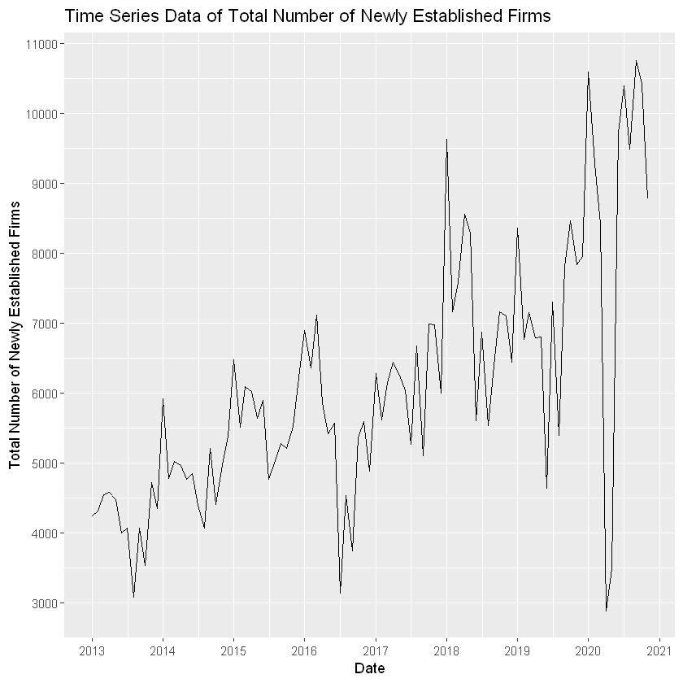

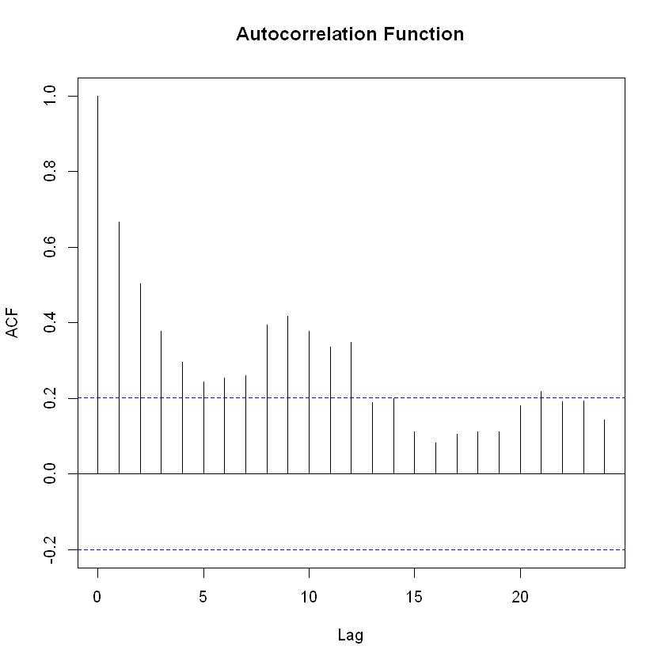

```r
ggplot(data=newly_established_firms, aes(x=Date, y=Total_Number)) + geom_line() +
scale_x_date(date_labels ="%Y",  date_breaks = "1 year") +
scale_y_continuous(breaks=seq(0, 11000, by = 1000)) +
labs( x = "Date", y = "Total Number of Newly Established Firms",title ="Time Series Data of Total Number of Newly Established Firms")
acf(newly_established_firms[,2],lag.max = 24,main = "Autocorrelation Function")
```

From the plot of time Series Data of total number of newly established firms and its autocorrelation function, it is easily observed that time series data have yearly and monthly seasonalities and trend component. Effects of some special days also can be obvserved from the plot.

#### Adding monthly and yearly seasonality factors to time series data

```r
months <- c("January","February","March","April","May","June","July","August","September","October","November","December")
moy <- rep(months,7)
moy <- c(moy,months[1:11])
newly_established_firms[,moy:=moy]
newly_established_firms[,Year:=year(Date)]
newly_established_firms[,Trend := 1:.N]
```

#### Creating a model with seasonality factors and trend

```
Call:
lm(formula = Total_Number ~ Trend + moy, data = newly_established_firms)

Residuals:
    Min      1Q  Median      3Q     Max
-4846.1  -471.9    47.8   443.5  2757.2

Coefficients:
             Estimate Std. Error t value Pr(>|t|)
(Intercept)  3612.291    481.559   7.501 6.74e-11 ***
Trend          46.725      4.605  10.147 3.83e-16 ***
moyAugust    -472.899    611.880  -0.773  0.44183
moyDecember    34.640    633.136   0.055  0.95650
moyFebruary   556.449    611.672   0.910  0.36564
moyJanuary   1676.424    611.759   2.740  0.00753 **
moyJuly      -128.174    611.759  -0.210  0.83456
moyJune       -65.574    611.672  -0.107  0.91489
moyMarch      794.475    611.620   1.299  0.19760
moyMay       -167.850    611.620  -0.274  0.78444
moyNovember   348.302    612.452   0.569  0.57111
moyOctober    399.152    612.227   0.652  0.51625
moySeptember   49.127    612.036   0.080  0.93622
---
Signif. codes:  0 '***' 0.001 '**' 0.01 '*' 0.05 '.' 0.1 ' ' 1

Residual standard error: 1223 on 82 degrees of freedom
Multiple R-squared:  0.5899,	Adjusted R-squared:  0.5299
F-statistic:  9.83 on 12 and 82 DF,  p-value: 1.429e-11
```

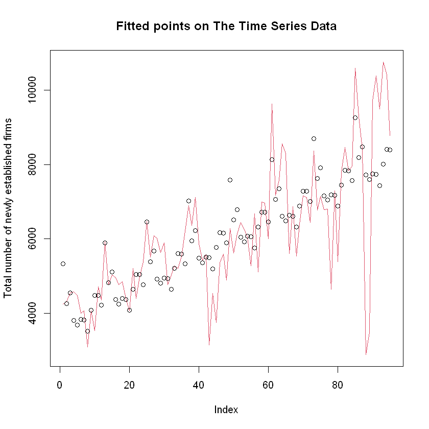

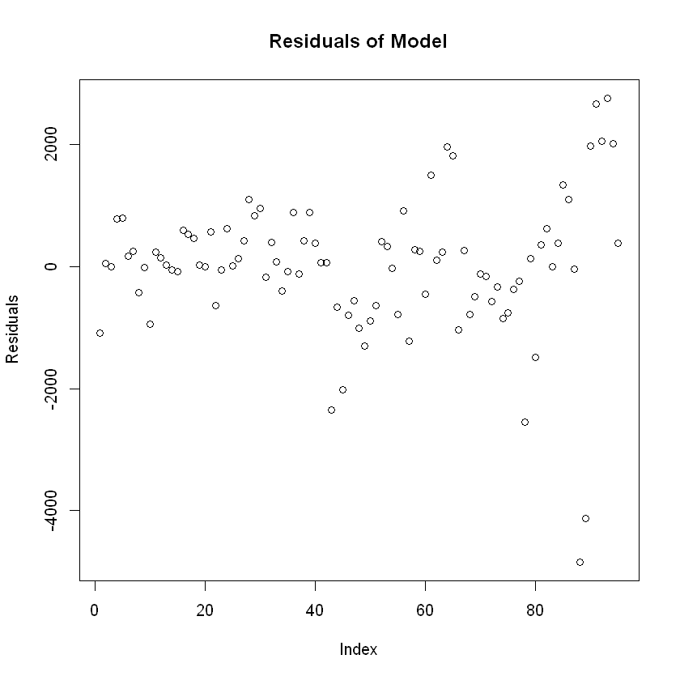

```
	Breusch-Godfrey test for serial correlation of order up to 16

data:  Residuals
LM test = 38.119, df = 16, p-value = 0.001455
```

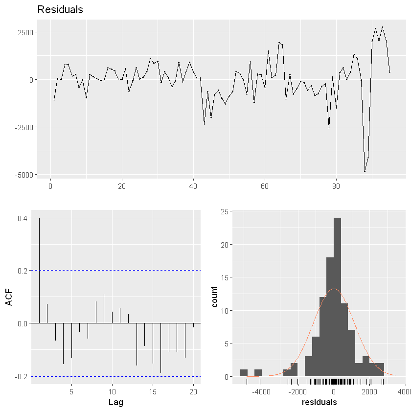

```r
fit=lm(Total_Number~Trend + moy,newly_established_firms)
newly_established_firms[,fitted:=fitted(fit)]
newly_established_firms[,residual:=residuals(fit)]
summary(fit)

plot(newly_established_firms$Total_Number,type='l',col=2,xlab = "Index",ylab = "Total number of newly established firms",
    main = "Fitted points on The Time Series Data")
points(fit$fitted)

plot(fit$residual,xlab = "Index", ylab = "Residuals", main = "Residuals of Model")

checkresiduals(fit)
```

#### Reading and manipulating some independent variables which can explain the behavior of time series data of total numbers of newly establised firms

```r
setnames(interest_rate,colnames(interest_rate[,2]),"Interest_rate")
interest_rate[,Interest_rate:=gsub("\\,","\\.",Interest_rate)]
interest_rate[,2 := as.numeric(Interest_rate)]
newly_established_firms[,Interest_rate:= interest_rate[,2]]
interest_rate[,1 := as.Date(paste(Date,"-01",sep="",format = "%Y-%m-%d"))]

setnames(exchange_rate_to_dollar,colnames(exchange_rate_to_dollar[,2]),"Exchange_rates")
exchange_rate_to_dollar[,Exchange_rates:=gsub("\\,","\\.",Exchange_rates)]
exchange_rate_to_dollar[,2 := as.numeric(Exchange_rates)]
newly_established_firms[,Exchange_rates:= exchange_rate_to_dollar[,2]]
exchange_rate_to_dollar[,1 := as.Date(paste(Tarih,"-01",sep="",format = "%Y-%m-%d"))]

setnames(confidence,colnames(confidence[,2]),"Confidence_Index")
confidence[,Confidence_Index:=gsub("\\,","\\.",Confidence_Index)]
confidence[,2 := as.numeric(Confidence_Index)]
newly_established_firms[,Confidence_Index:= confidence[,Confidence_Index]]
confidence[,1 := as.Date(paste(Date,"-01",sep="",format = "%Y-%m-%d"))]
```

Time series data of exchange rate from dollar to turkish liras, time series data of interest rate on commerical loans and time series data of seasonally adjusted confidence index which have some behavior similar to time series data of total number of newly establised firms can explain the behavior of this time series data. It is also known from economics knowledge that interest rate on commercial loans, exchange rate from dollar to turkish liras and seasonally adjusted confidence index should affect the total number of newly established firms.

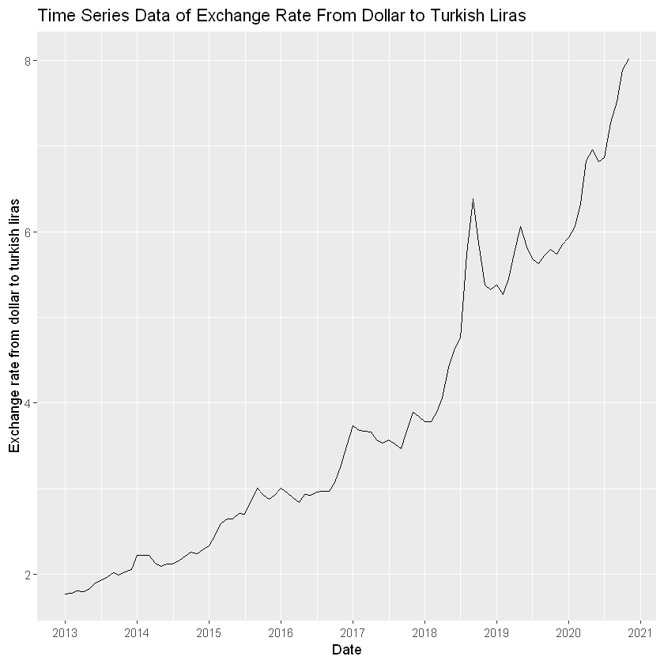

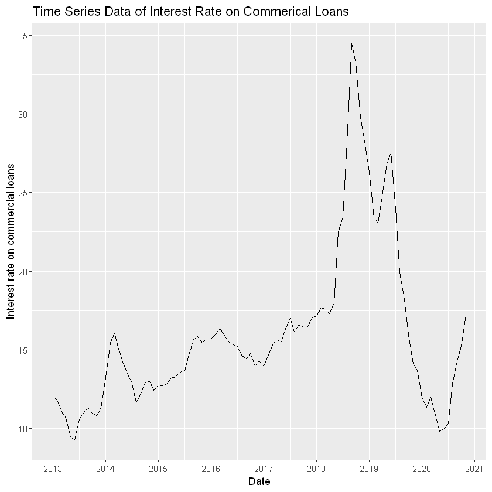

[figure not shown]

```r
ggplot(data=newly_established_firms, aes(x=Date, y=Exchange_rates)) + geom_line() +
scale_x_date(date_labels ="%Y",  date_breaks = "1 year") +
labs( x = "Date", y = "Exchange rate from dollar to turkish liras",title ="Time Series Data of Exchange Rate From Dollar to Turkish Liras")

ggplot(data=newly_established_firms, aes(x=Date, y=Interest_rate)) + geom_line() +
labs( x = "Date", y = "Interest rate on commercial loans",title ="Time Series Data of Interest Rate on Commerical Loans") +
scale_x_date(date_labels ="%Y",  date_breaks = "1 year")

ggplot(data=confidence, aes(x=Date, y=Confidence_Index)) + geom_line() +
labs( x = "Date", y = "Interest rate on commercial loans",title ="Time Series Data of Seasonally Adjusted Confidence Index") +
scale_x_date(date_labels ="%Y",  date_breaks = "1 year")
```

Seen from graphs, There are some peaks that affects the performance of the model which is created by using monthly and yearly factors, interest rate on commerical loans, exchange rate from dollar to turkish liras and seasonally adjusted confidence index. These peaks should be analyzed further to improve the model. Also year can be removed from model since it has singularities.

```
Call:
lm(formula = Total_Number ~ Trend + moy + Year + Interest_rate +
    Exchange_rates + Confidence_Index, data = newly_established_firms)

Residuals:
    Min      1Q  Median      3Q     Max
-5131.5  -373.5    29.1   547.6  2180.7

Coefficients: (1 not defined because of singularities)
                 Estimate Std. Error t value Pr(>|t|)
(Intercept)       -634.08    4233.37  -0.150  0.88132
Trend               39.14      15.78   2.480  0.01525 *
moyAugust         -488.30     608.92  -0.802  0.42502
moyDecember        163.10     635.78   0.257  0.79820
moyFebruary        687.15     617.58   1.113  0.26923
moyJanuary        1755.18     611.32   2.871  0.00525 **
moyJuly           -132.22     608.77  -0.217  0.82862
moyJune            -71.89     608.69  -0.118  0.90628
moyMarch           874.39     611.13   1.431  0.15644
moyMay            -194.77     608.29  -0.320  0.74967
moyNovember        353.72     609.10   0.581  0.56307
moyOctober         475.17     611.50   0.777  0.43945
moySeptember       124.08     611.65   0.203  0.83977
Year                   NA         NA      NA       NA
Interest_rate      -37.31      27.38  -1.362  0.17697
Exchange_rates     301.92     293.56   1.028  0.30687
Confidence_Index    45.36      41.19   1.101  0.27413
---
Signif. codes:  0 '***' 0.001 '**' 0.01 '*' 0.05 '.' 0.1 ' ' 1

Residual standard error: 1216 on 79 degrees of freedom
Multiple R-squared:  0.6095,	Adjusted R-squared:  0.5354
F-statistic: 8.221 on 15 and 79 DF,  p-value: 7.523e-11
```

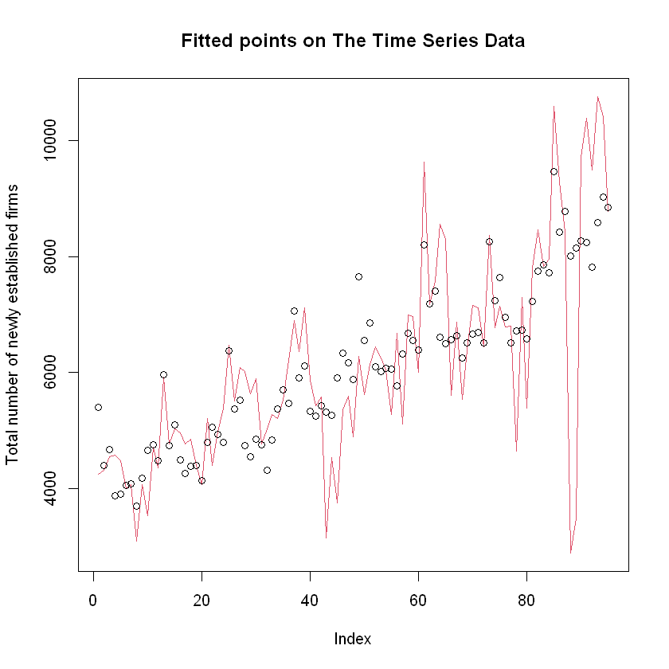

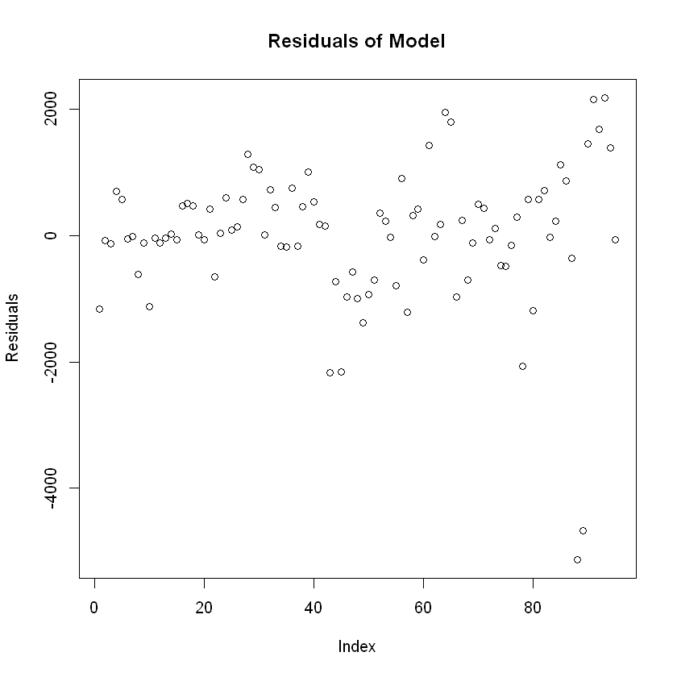

```
	Breusch-Godfrey test for serial correlation of order up to 20

data:  Residuals
LM test = 41.304, df = 20, p-value = 0.003405
```

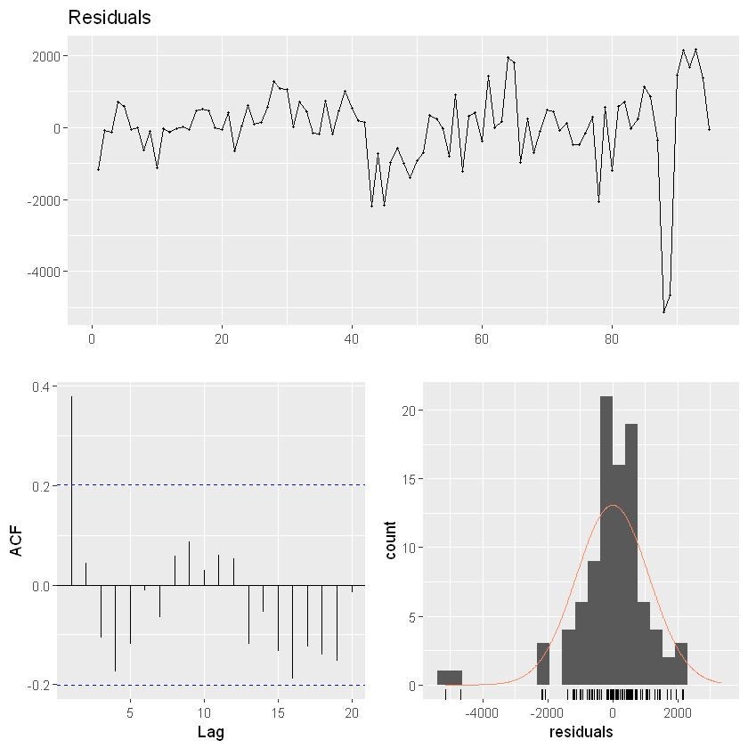

```r
fit=lm(Total_Number~Trend + moy + Year + Interest_rate +  Exchange_rates + Confidence_Index ,newly_established_firms)
newly_established_firms[,fitted:=fitted(fit)]
newly_established_firms[,residual:=residuals(fit)]
summary(fit)

plot(newly_established_firms$Total_Number,type='l',col=2,xlab = "Index",ylab = "Total number of newly established firms",
    main = "Fitted points on The Time Series Data")
points(fit$fitted)

plot(fit$residual,xlab = "Index", ylab = "Residuals", main = "Residuals of Model")

checkresiduals(fit)
```

```r
newly_established_firms[Date=="2016-07-01",coup := 1]
newly_established_firms[is.na(coup) == T,coup := 0]
newly_established_firms[Date=="2020-04-01" | Date =="2020-05-01",corona := 1]
newly_established_firms[is.na(corona) == T,corona := 0]
```

```
Call:
lm(formula = Total_Number ~ Trend + moy + Interest_rate + Exchange_rates +
    Confidence_Index + as.factor(coup) + as.factor(corona), data = newly_established_firms)

Residuals:
     Min       1Q   Median       3Q      Max
-1919.48  -432.50    38.66   398.47  1634.55

Coefficients:
                   Estimate Std. Error t value Pr(>|t|)
(Intercept)         2045.50    2687.16   0.761 0.448856
Trend                 34.08      10.04   3.393 0.001093 **
moyAugust          -1360.83     392.41  -3.468 0.000862 ***
moyDecember         -661.20     407.56  -1.622 0.108823
moyFebruary         -164.20     396.78  -0.414 0.680149
moyJanuary           920.08     392.76   2.343 0.021735 *
moyJuly             -674.79     405.42  -1.664 0.100097
moyJune             -896.76     391.25  -2.292 0.024636 *
moyMarch              32.51     392.76   0.083 0.934237
moyMay              -221.79     383.15  -0.579 0.564362
moyNovember         -549.57     393.06  -1.398 0.166073
moyOctober          -422.92     394.31  -1.073 0.286816
moySeptember        -756.18     394.11  -1.919 0.058733 .
Interest_rate        -97.11      18.12  -5.360  8.4e-07 ***
Exchange_rates       558.86     189.67   2.946 0.004251 **
Confidence_Index      27.13      26.09   1.040 0.301771
as.factor(coup)1   -2310.50     828.62  -2.788 0.006671 **
as.factor(corona)1 -6799.01     640.42 -10.617  < 2e-16 ***
---
Signif. codes:  0 '***' 0.001 '**' 0.01 '*' 0.05 '.' 0.1 ' ' 1

Residual standard error: 766 on 77 degrees of freedom
Multiple R-squared:  0.849,	Adjusted R-squared:  0.8157
F-statistic: 25.47 on 17 and 77 DF,  p-value: < 2.2e-16
```

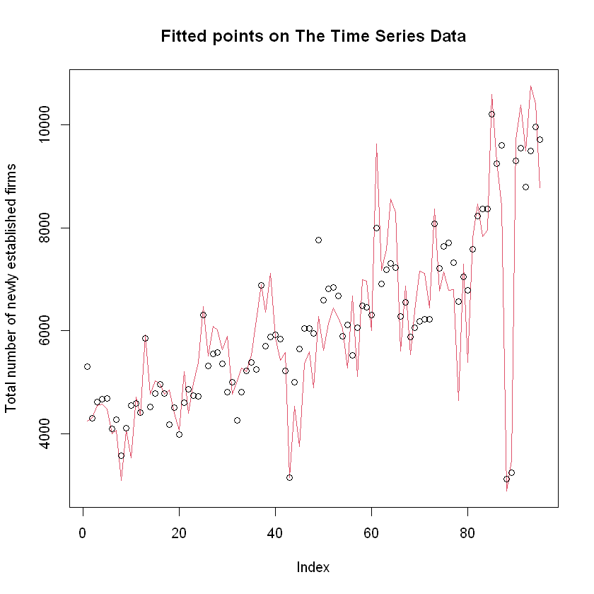

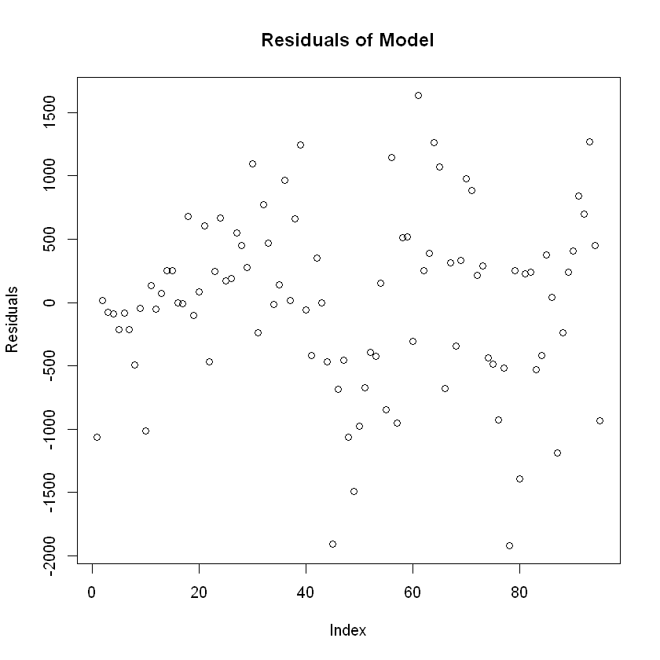

```
	Breusch-Godfrey test for serial correlation of order up to 21

data:  Residuals
LM test = 43.952, df = 21, p-value = 0.002372
```

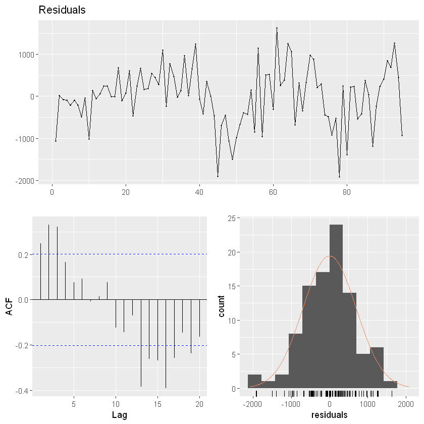

```r
fit=lm(Total_Number~Trend + moy + Interest_rate +  Exchange_rates + Confidence_Index + as.factor(coup) + as.factor(corona) ,newly_established_firms)
newly_established_firms[,fitted:=fitted(fit)]
newly_established_firms[,residual:=residuals(fit)]
summary(fit)

plot(newly_established_firms$Total_Number,type='l',col=2,xlab = "Index",ylab = "Total number of newly established firms",
    main = "Fitted points on The Time Series Data")
points(fit$fitted)

plot(fit$residual,xlab = "Index", ylab = "Residuals", main = "Residuals of Model")

checkresiduals(fit)
```

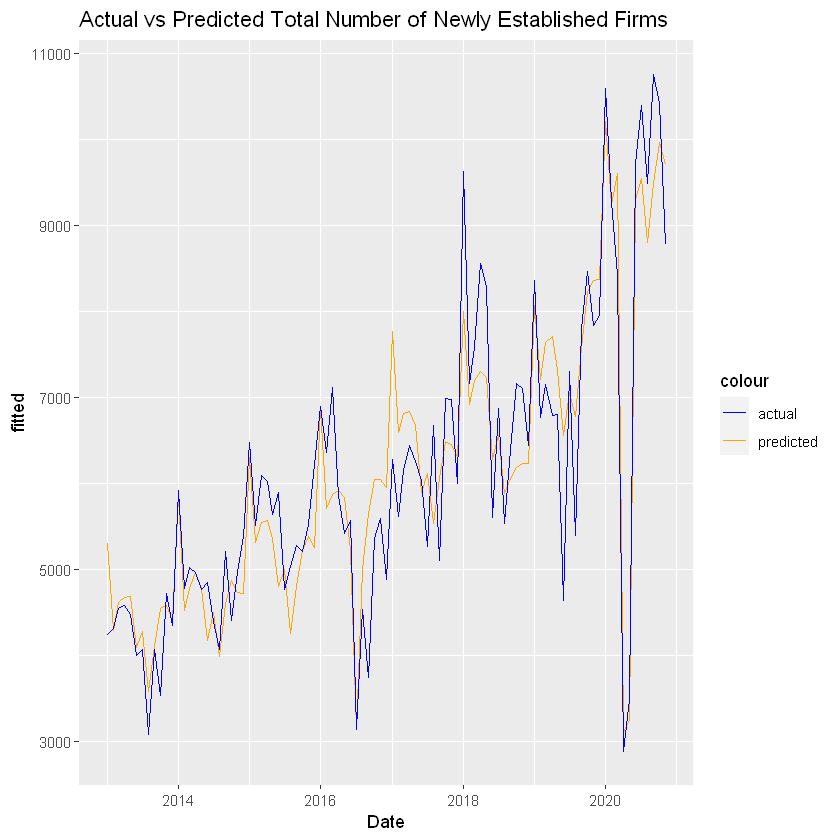

```r
cols <- c("predicted" = "orange", "actual" = "blue")
ggplot() +
  geom_line(data = newly_established_firms, aes(x = Date, y = fitted,color = "predicted")) +
  geom_line(data = newly_established_firms, aes(x = Date, y = Total_Number,color = "actual")) +
  labs(xlab = "Date",ylab = 'Total number of newly established firms',
       title = 'Actual vs Predicted Total Number of Newly Established Firms' ) +
  scale_color_manual(values = cols)
```

```r
t12 <- "2020-12-01"
newly_established_firms <- rbind(newly_established_firms,data.table(Date = as.Date(t12)),fill = TRUE)
newly_established_firms[.N,Interest_rate:= newly_established_firms[.N-1,Interest_rate]]
newly_established_firms[.N,Exchange_rates:= newly_established_firms[.N-1,Exchange_rates]]
newly_established_firms[.N,Confidence_Index:= newly_established_firms[.N-1,Confidence_Index]]
newly_established_firms[.N,Trend:= 96]
newly_established_firms[.N,coup:= 0]
newly_established_firms[.N,corona:= 0]
newly_established_firms[.N,Year:= 2021]
newly_established_firms[.N,moy:= "December"]
newly_established_firms[is.na(fitted)==T,fitted:=predict(fit,newly_established_firms[is.na(fitted)==T])]
tail(newly_established_firms)
newly_established_firms[.N,fitted]
```

A data.table: 6 × 12

| Date <date> | Total_Number <dbl> | moy <chr> | Year <dbl> | Trend <int> | Interest_rate <dbl> | Exchange_rates <dbl> | Confidence_Index <dbl> | fitted <dbl> | residual <dbl> | coup <dbl> | corona <dbl> |
| --- | --- | --- | --- | --- | --- | --- | --- | --- | --- | --- | --- |
| 2020-07-01 | 10394 | July | 2020 | 91 | 10.30 | 6.86 | 82.82 | 9551.981 | 842.0188 | 0 | 0 |
| 2020-08-01 | 9496 | August | 2020 | 92 | 12.85 | 7.27 | 79.77 | 8798.772 | 697.2282 | 0 | 0 |
| 2020-09-01 | 10764 | September | 2020 | 93 | 14.29 | 7.52 | 81.91 | 9495.437 | 1268.5631 | 0 | 0 |
| 2020-10-01 | 10419 | October | 2020 | 94 | 15.23 | 7.89 | 81.54 | 9968.224 | 450.7763 | 0 | 0 |
| 2020-11-01 | 8782 | November | 2020 | 95 | 17.19 | 8.02 | 79.98 | 9715.650 | -933.6504 | 0 | 0 |
| 2020-12-01 | NA | December | 2021 | 96 | 17.19 | 8.02 | 79.98 | 9638.096 | NA | 0 | 0 |

9638.09618225136

### Conclusion

In order to have a good model, autocorrelation function and plots of time series data is analyzed in order to observe the seasonality factors and these seasonality factors, independent variables which is known as the affecting factor from knowledge or is observed as the affecting factor from plots and trend component which is also observed from plots are used in model.

There are still some residuals which is very high or very low in value. These points should be analyzed further and added to model in order to get a better model than the current model.

Prediction of twelfth month of 2020 is 9638.096. It will be checked when electronic data delivery system adds the next month's data.